# combined model

Talladega Bites

2025-04-02

#Talladega Bites

```r
#remotes::install_github("eco4cast/neon4cast")
library(tidyverse)
library(neon4cast)
library(lubridate)
library(rMR)
library(arrow)
library(rjags)
```

```r
require(ggplot2)
library(dplyr)
library(tidyr)
#install.packages("scales")
library(scales)
```

# Tick Data

(manually parsed)

```r
dat <- read.csv("monthly_tick_temp.csv")
dat <- dat[1:58, c("month.year", "tick")]# # drops unneeded columns and NA rows
```

```r
t = dat[1:58,1] #time
```

# Quick Model Summary

##TODO: Can someone fix this (and list what the terms are) so it’s the same as what we actually have in model

$$X_i = r \cdot X_{i-1} \cdot \left(1 - \frac{X_{i-1}}{K} \right) + E_i$$

```r
# Convert 'month.year' to a Date object
dat$Date <- as.Date(paste0(dat$month.year, "-01"))

# Calculate time step differences in months
dat$TimeStep <- c(NA, diff(as.numeric(format(dat$Date, "%Y")) * 12 + as.numeric(format(dat$Date, "%m"))))

dat$tick <- round(dat$tick)

head(dat)
```

```
##   month.year tick       Date TimeStep
## 1    2015-06   81 2015-06-01       NA
## 2    2015-07   84 2015-07-01        1
## 3    2015-08   45 2015-08-01        1
## 4    2015-09   48 2015-09-01        1
## 5    2015-10   16 2015-10-01        1
## 6    2015-11    0 2015-11-01        1
```

```r
tick <- dat$tick
data <- list(tick = tick, n = length(t))
```

```r
log_solution_model <- "
model{

  ## priors
  ## tau (time between steps) from the dataframe
  K ~ dnorm(300,0.01)     # from our 'literature review'
  r ~ dnorm(0,0.01)       # uninformative prior on rate
  sigma ~ dgamma(0.1,0.1) ## sigma is E's precision for one month

  N[1] ~ dnorm(N_ic, tau_N_ic)  # Latent state initial value
  N_ic ~ dnorm(0, 0.1)        # Prior for initial state
  tau_N_ic ~ dgamma(0.1, 0.1)   # Precision on initial state

  ## process model
    for(i in 2:Ni){
      tau_E[i] <- sigma^tau[i]   # sigma is multiplicative for multiple months
      E[i] ~ dnorm(0, tau_E[i])
      N[i] <- max(0,((K*N[i-1]) / (N[i-1] + (K-N[i-1]))*exp(-r*tau[i])) + E[i])  # wrapped in max so E[i] doesn't drag N[i] <0
    }

  ## data model
    for(i in 1:Ni){
      y[i] ~ dpois(max(0.001, N[i]))  # Ensures positive values only
    }
}
"
```

```r
data <- list(y=dat$tick,
             Ni=length(dat$tick),
             tau=dat$TimeStep
             )

j.model   <- jags.model (file = textConnection(log_solution_model),
                             data = data,
                             n.chains = 5)
```

```r
out_1 <- coda.samples(model = j.model,
                      variable.names = c("r", "E", "N", "K", "sigma"),
                      n.iter = 150000,
                      burnin = 10000)
```

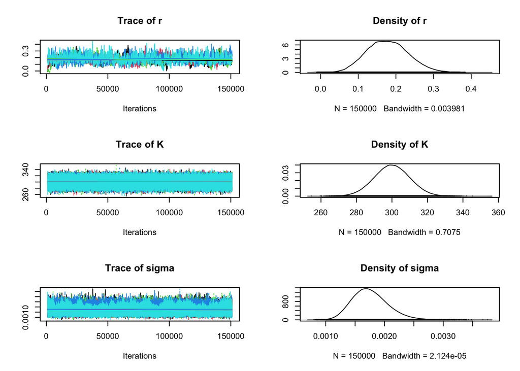

```r
plot(out_1[, c("r", "K", "sigma")])
```

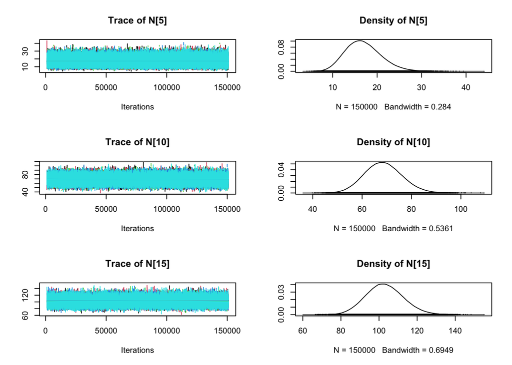

```r
plot(out_1[, c("N[5]", "N[10]", "N[15]")])
```

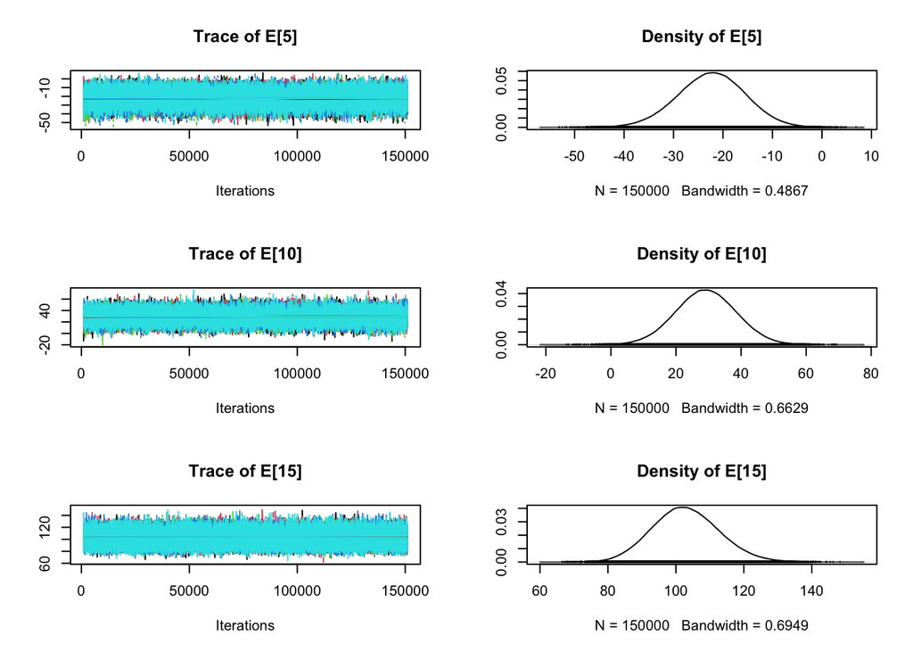

```r
plot(out_1[, c("E[5]", "E[10]", "E[15]")])
```

# Diagnostics

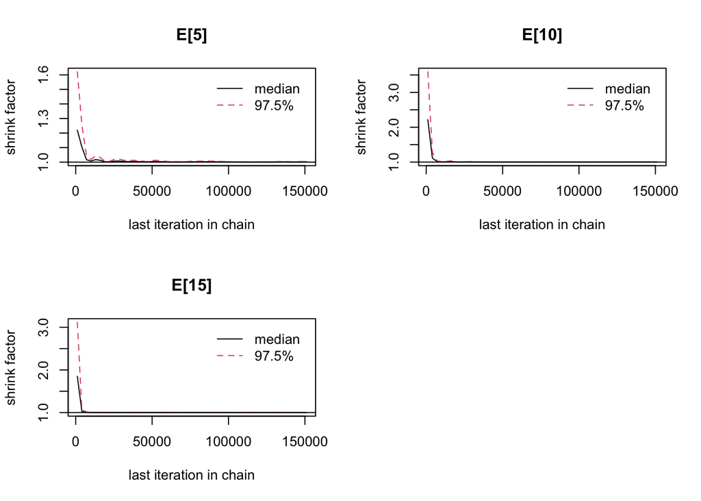

```r
gelman.plot(out_1[, c("E[5]", "E[10]", "E[15]")])
```

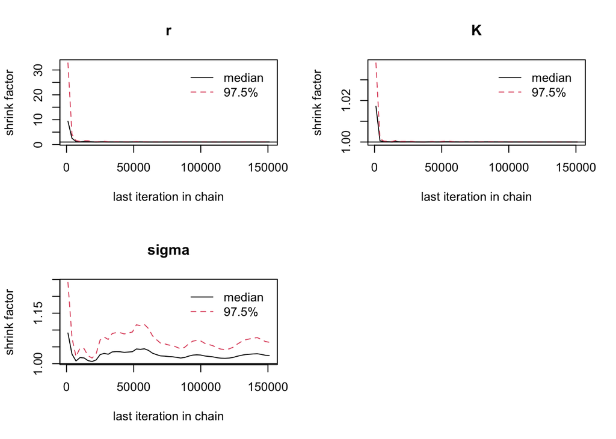

```r
gelman.plot(out_1[, c("r", "K", "sigma")])
```

```r
gelman.diag(out_1[, c("r", "sigma", "K",
                      "N[5]", "N[10]", "N[15]",
                      "E[5]", "E[10]", "E[15]"
                      )])
```

```
## Potential scale reduction factors:
##
##       Point est. Upper C.I.
## r           1.04       1.09
## sigma       1.02       1.06
## K           1.00       1.00
## N[5]        1.00       1.00
## N[10]       1.00       1.00
## N[15]       1.00       1.00
## E[5]        1.00       1.01
## E[10]       1.00       1.01
## E[15]       1.00       1.00
##
## Multivariate psrf
##
## 1.04
```

# Posterior summary statistics

```r
summary(out_1[, c("r", "K", "sigma",
                  "N[5]", "N[10]", "N[15]",
                  "E[5]", "E[10]", "E[15]")])
```

```
##
## Iterations = 1001:151000
## Thinning interval = 1
## Number of chains = 5
## Sample size per chain = 150000
##
## 1. Empirical mean and standard deviation for each variable,
##    plus standard error of the mean:
##
##             Mean        SD  Naive SE Time-series SE
## r       0.177427 0.0561952 6.489e-05      2.460e-03
## K     299.988217 9.9875655 1.153e-02      1.459e-02
## sigma   0.001758 0.0003046 3.517e-07      1.515e-06
## N[5]   16.918627 4.0143630 4.635e-03      6.442e-03
## N[10]  68.580499 7.5680061 8.739e-03      3.502e-02
## N[15] 102.959366 9.8086808 1.133e-02      5.860e-02
## E[5]  -22.339856 6.8802754 7.945e-03      3.715e-02
## E[10]  29.213468 9.3667490 1.082e-02      5.563e-02
## E[15] 102.950322 9.8090460 1.133e-02      5.861e-02
##
## 2. Quantiles for each variable:
##
##             2.5%        25%        50%        75%      97.5%
## r       0.073547   0.138399   0.176127   0.214778   0.290967
## K     280.388568 293.280588 299.969358 306.716429 319.591169
## sigma   0.001233   0.001543   0.001733   0.001945   0.002425
## N[5]    9.947813  14.066592  16.616138  19.438436  25.612147
## N[10]  54.416074  63.347526  68.359730  73.553912  84.068244
## N[15]  84.582637  96.207771 102.665717 109.409585 123.044930
## E[5]  -36.144984 -26.891561 -22.238619 -17.685880  -9.084583
## E[10]  10.861139  22.937087  29.176868  35.476114  47.628227
## E[15]  84.568553  96.198084 102.658420 109.401139 123.037952
```

```r
combined_mcmc <- as.mcmc(do.call(rbind, out_1))

# convert to data frame
params_df <- as.data.frame(combined_mcmc)

params_subset <- params_df[, c("r", "K", "sigma",
                               "N[5]", "N[10]", "N[15]",
                               "E[5]", "E[10]", "E[15]")]
head(params_subset)
```

```
##              r        K       sigma     N[5]    N[10]     N[15]      E[5]
## 1 -0.005262663 284.1997 0.001677235 15.20724 73.05493 103.32507 -26.78077
## 2 -0.004978772 310.5465 0.001684981 22.47945 71.37409 104.22414 -24.50498
## 3 -0.004672218 316.5297 0.001986481 13.86212 73.04278 101.13804 -27.47757
## 4 -0.003505011 298.0180 0.001661302 26.73319 73.13965  99.71486 -25.90205
## 5 -0.002807267 310.1324 0.001961300 12.76091 71.19008  98.20925 -30.39671
## 6 -0.002614141 295.4144 0.001958002 15.07510 72.75679  99.49966 -23.32385
##         E[10]     E[15]
## 1  6.05554356 103.32507
## 2  2.88159535 104.22414
## 3  0.75671340 101.13804
## 4  2.17066942  99.71486
## 5  0.05423187  98.20925
## 6 -1.45863606  99.49966
```

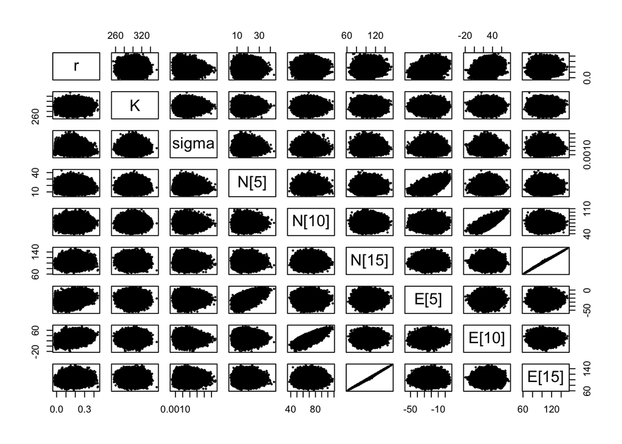

```r
pairs(params_subset, pch = 1, cex = 0.3)
```

# Time Series

```r
# Flatten MCMC output
out_matrix <- as.matrix(out_1)

# Time vector
time <- 1:length(dat$tick)

# Extract latent state samples
X_samples <- out_matrix[, grep("^N\\[", colnames(out_matrix))]

# Compute posterior summaries
X_median <- apply(X_samples, 2, median)
X_CI <- apply(X_samples, 2, quantile, probs = c(0.025, 0.975))
```

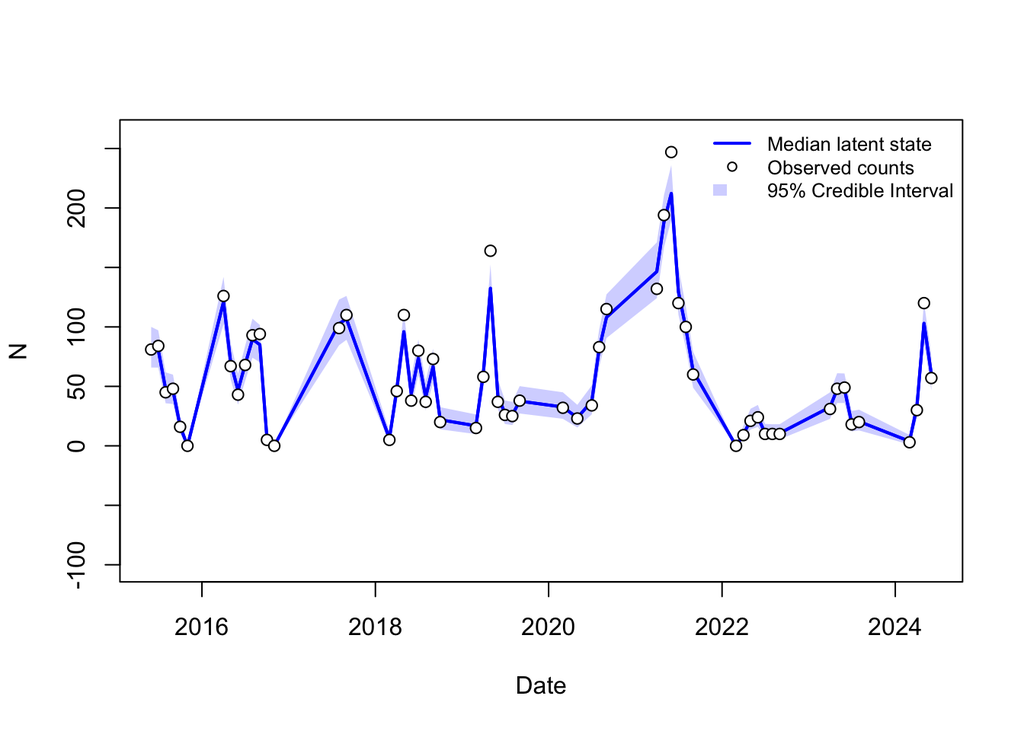

```r
# Base plot
plot(dat$Date, X_median, type = 'l', lwd = 2, col = "blue", ylim = c(-100, max(X_CI[2,]) * 1.1),
     ylab = "N", xlab = "Date")

# 95% Credible interval as blue ribbon
polygon(c(dat$Date, rev(dat$Date)),
        c(X_CI[1,], rev(X_CI[2,])),
        col = rgb(0, 0, 1, 0.2), border = NA)

# Add median line again on top of ribbon
lines(dat$Date, X_median, col = "blue", lwd = 2)

# Observed data points
points(dat$Date, data$y, pch = 21, bg = "white")

legend("topright",
       legend = c("Median latent state", "Observed counts", "95% Credible Interval"),
       col = c("blue", "black", NA),
       lwd = c(2, NA, NA),
       pch = c(NA, 21, NA),
       pt.bg = c(NA, "white", NA),
       fill = c(NA, NA, rgb(0, 0, 1, 0.2)),  # Add fill for CI
       border = c(NA, NA, NA),              # No border for fill
       bty = "n",
       cex = 0.8)
```

# Forecasting

```r
N_forecast <- 12
Ni_obs <- length(dat$tick)

# Extend y with 12 NAs
y_full <- c(dat$tick, rep(NA, N_forecast))

# Assume constant monthly step from last timestep
# If TimeStep is in months (e.g., 1, 2, 3...), this just extends linearly
last_tau <- tail(dat$TimeStep, 1)
tau_forecast <- rep(1, N_forecast)  # each new step is 1 month
tau_full <- c(dat$TimeStep, tau_forecast)

# Total time points
Ni <- length(y_full)

data_forecast <- list(
  y = y_full,
  tau = tau_full,
  Ni = Ni
)
```

```r
j.model <- jags.model(
  file = textConnection(log_solution_model),
  data = data_forecast,
  n.chains = 5
)
out_forecast <- coda.samples(
  model = j.model,
  variable.names = c("r", "E", "N", "K", "sigma"),
  n.iter = 150000,
  burnin = 10000
)
```

```r
# Convert coda output to matrix
out_matrix <- as.matrix(out_forecast)

# Extract columns corresponding to N[...]
N_cols <- grep("^N\\[", colnames(out_matrix))
N_samples <- out_matrix[, N_cols]  # Each column is N[1], N[2], ..., N[Ni + 12]

# Confirm dimension
dim(N_samples)  # should be (n.iter * n.chains) rows by (Ni + 12) columns
```

```
## [1] 750000     70
```

```r
# Compute posterior median and 95% CI for each time point
N_median <- apply(N_samples, 2, median)
N_CI <- apply(N_samples, 2, quantile, probs = c(0.025, 0.975))
```

```r
Ni_obs <- length(dat$Date)
Ni_total <- ncol(N_samples)
Ni_forecast <- Ni_total - Ni_obs

# Extend date vector 12 months forward
future_dates <- seq(from = max(dat$Date) + 1, by = "month", length.out = Ni_forecast)
all_dates <- c(dat$Date, future_dates)

# Split CI and median into observed + forecast parts
X_median_obs <- N_median[1:Ni_obs]
X_CI_obs <- N_CI[, 1:Ni_obs]

X_median_forecast <- N_median[(Ni_obs + 1):Ni_total]
X_CI_forecast <- N_CI[, (Ni_obs + 1):Ni_total]

# Simulate Poisson predictive draws for forecast
N_forecast_samples <- N_samples[, (Ni_obs + 1):Ni_total]  # latent forecasts

# Matrix of predictive draws, same shape as N_forecast_samples
Y_pred_samples <- matrix(rpois(length(N_forecast_samples),
                               lambda = pmax(0.001, N_forecast_samples)),
                         nrow = nrow(N_forecast_samples))


Y_PI_forecast <- apply(Y_pred_samples, 2, quantile, probs = c(0.025, 0.975))
```

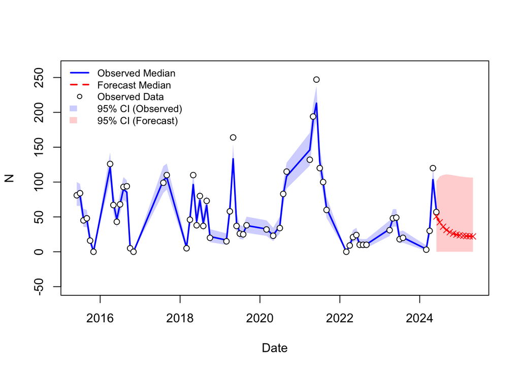

```r
# Base plot
plot(all_dates, N_median, type = 'n', ylim = c(-50, max(N_CI[2,]) * 1.1),
     ylab = "N", xlab = "Date")

# 95% CI for observed
polygon(c(dat$Date, rev(dat$Date)),
        c(X_CI_obs[1,], rev(X_CI_obs[2,])),
        col = rgb(0, 0, 1, 0.2), border = NA)

# 95% CI for forecast
polygon(c(future_dates, rev(future_dates)),
        c(X_CI_forecast[1,], rev(X_CI_forecast[2,])),
        col = rgb(1, 0, 0, 0.2), border = NA)

# Median lines
lines(dat$Date, X_median_obs, col = "blue", lwd = 2)
lines(future_dates, X_median_forecast, col = "red", lwd = 2, lty = 2)

# Observed data points
points(dat$Date, data$y, pch = 21, bg = "white")

# Forecasted points
points(future_dates, X_median_forecast, pch = 4, bg = "red", col = "red")

# Legend
legend("topleft",
       legend = c("Observed Median", "Forecast Median", "Observed Data",
                  "95% CI (Observed)", "95% CI (Forecast)"),
       col = c("blue", "red", "black", NA, NA),
       lwd = c(2, 2, NA, NA, NA),
       lty = c(1, 2, NA, NA, NA),
       pch = c(NA, NA, 21, NA, NA),
       pt.bg = c(NA, NA, "white", NA, "red", NA),
       fill = c(NA, NA, NA,
                rgb(0, 0, 1, 0.2),
                rgb(1, 0, 0, 0.2),
                rgb(1, 0.7, 0, 0.2)),
       border = NA, bty = "n", cex = 0.8)
```

# Uncertainty Partitioning

Now, we have to partition our uncertainty. The median line above is our deterministic prediction. We will zoom in on 2023 and onward in the plot to better see our uncertainty, and take out the confidence interval for the forecasting period from before.

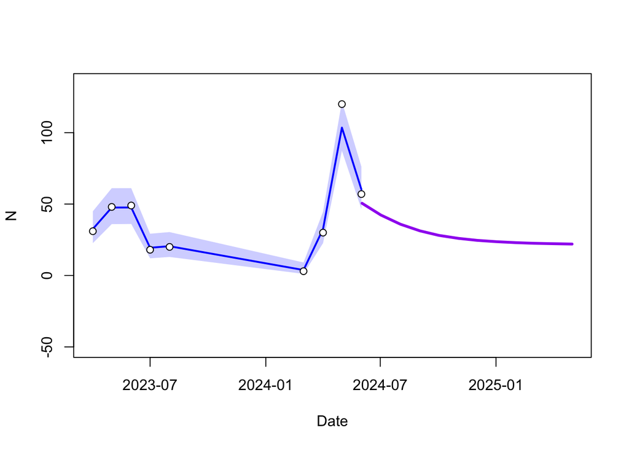

```r
dat$Date <- as.Date(paste0(dat$month.year, "-01"))
# Define cutoff date
cutoff_date <- as.Date("2023-01-01")

# Filter indices for zooming
zoom_idx_all <- which(all_dates >= cutoff_date)
zoom_idx_obs <- which(dat$Date >= cutoff_date)
zoom_idx_forecast <- which(future_dates >= cutoff_date)

zoomed_plot <- function() {
  # Base plot (zoomed)
  plot(all_dates[zoom_idx_all], N_median[zoom_idx_all], type = 'n',
       ylim = c(-50, max(N_CI[2, zoom_idx_all]) * 1.1),
       ylab = "N", xlab = "Date")

  # 95% CI for observed
  polygon(c(dat$Date[zoom_idx_obs], rev(dat$Date[zoom_idx_obs])),
          c(X_CI_obs[1, zoom_idx_obs], rev(X_CI_obs[2, zoom_idx_obs])),
          col = rgb(0, 0, 1, 0.2), border = NA)

  # Median lines
  lines(dat$Date[zoom_idx_obs], X_median_obs[zoom_idx_obs], col = "blue", lwd = 2)
  lines(future_dates[zoom_idx_forecast], X_median_forecast[zoom_idx_forecast], col = "purple", lwd = 3, lty = 1)

  # Observed data points
  points(dat$Date[zoom_idx_obs], data$y[zoom_idx_obs], pch = 21, bg = "white")

}
zoomed_plot()
```

## Helper Functions

```r
set.seed(111)
##' @param IC    Vector of initial conditions (length = n)
##' @param r     Scalar intrinsic growth rate
##' @param K     Scalar carrying capacity
##' @param tau   Vector of time steps (length = steps)
##' @param n     Size of Monte Carlo ensemble
##' @param steps Number of forecast steps (default = 12)
forecastN <- function(IC, r, K, tau, n = 1000, steps = 12) {
  N <- matrix(NA, n, steps)       # Forecast matrix
  Nprev <- IC                     # Starting values (should be length n)

  for (t in 1:steps) {
    mu <- ((K * Nprev) / (Nprev + (K - Nprev))) * exp(-r * tau[t])
    N[, t] <- pmax(0, mu)         # Deterministic projection
    Nprev <- N[, t]               # Advance to next time step
  }

  return(N)
}


# helper to compute 95% CI and median
calc_forecast_ci <- function(fmat) {
  list(
    ci = apply(fmat, 2, quantile, probs = c(0.025, 0.975)),
    median = apply(fmat, 2, median)
  )
}

# helper to draw ci envelopes
draw_env <- function(ci, dates, col) {
  polygon(c(dates, rev(dates)),
          c(ci[1,], rev(ci[2,])),
          col = col, border = NA)
}
```

## Initial condition uncertainty

Let’s start by partitioning out the initial condition uncertainty.

```r
posterior <- as.matrix(out_forecast)

# Sample ICs from the posterior distribution of N[58] (last latent state)
IC <- sample(posterior[,"N[58]"], size = 1000, replace = TRUE)

# Fix other parameters using posterior mean or a draw
r <- mean(posterior[, "r"])
K <- mean(posterior[, "K"])
tau_forecast <- rep(1, 12)  # constant 1-month steps

# Forecast
N.I <- forecastN(IC = IC, r = r, K = K, tau = tau_forecast, n = 1000, steps = 12)
```

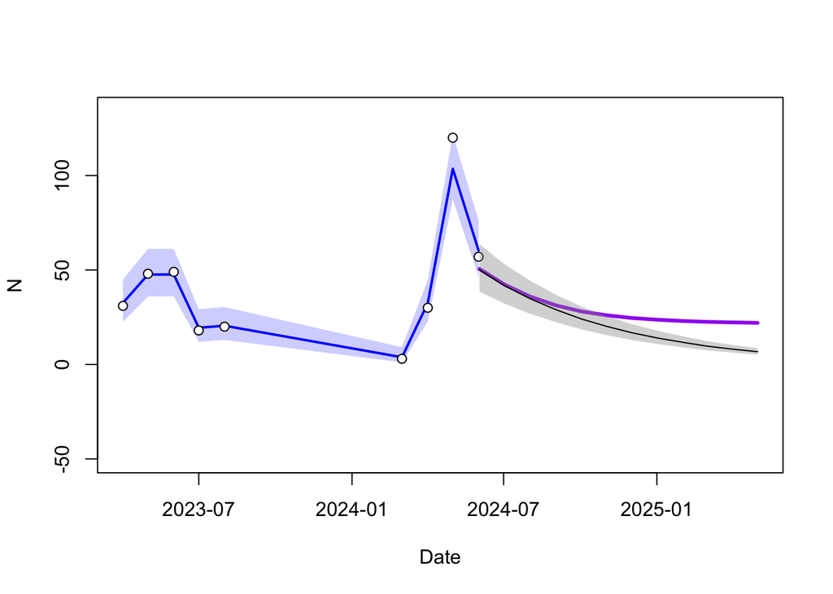

```r
N.I.ci <- apply(N.I, 2, quantile, c(0.025, 0.5, 0.975))

zoomed_plot()
ecoforecastR::ciEnvelope(future_dates, N.I.ci[1,], N.I.ci[3,], col = rgb(0.6, 0.6, 0.6, 0.4))
lines(future_dates, N.I.ci[2,], col = "black", lwd = 1)
```

## Initial Ccondition uncertainty + Parameter uncertainty

```r
n.mc <- 1000
steps <- 12
tau_forecast <- rep(1, steps)

# Sample ensemble from posterior
rows <- sample(1:nrow(posterior), n.mc, replace = TRUE)

ICs <- posterior[rows, "N[58]"]
rs  <- posterior[rows, "r"]
Ks  <- posterior[rows, "K"]

# Forecast with varying IC + param, no process noise
N.IP <- forecastN(IC = ICs, r = rs, K = Ks, tau = tau_forecast, n = n.mc, steps = steps)

# Summarize
N.IP.ci <- apply(N.IP, 2, quantile, probs = c(0.025, 0.5, 0.975))
```

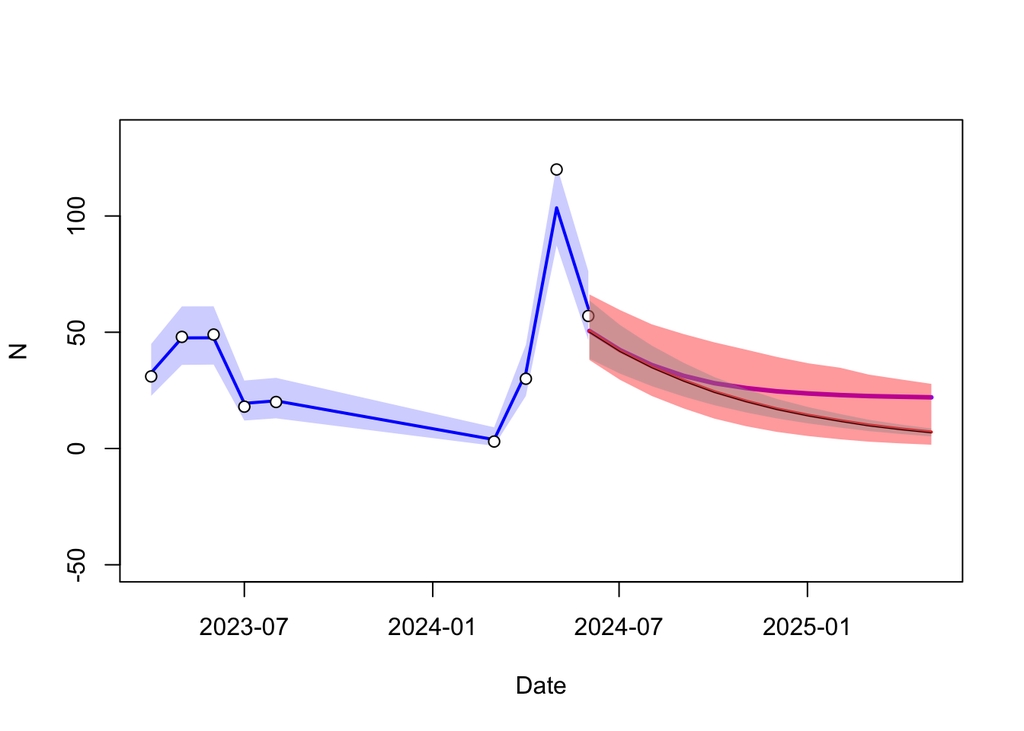

```r
zoomed_plot()

# Red envelope for N.IP
ecoforecastR::ciEnvelope(future_dates, N.IP.ci[1,], N.IP.ci[3,], col = rgb(1, 0, 0, 0.4))  # red with transparency
lines(future_dates, N.IP.ci[2,], lwd = 2, col = "red")

# envelope for N.I (initial condition only)
ecoforecastR::ciEnvelope(future_dates,N.I.ci[1,],N.I.ci[3,],col=rgb(0.6, 0.6, 0.6, 0.4))
lines(future_dates,N.I.ci[2,],lwd=0.5)
```

*Note*: we do not have any environmental drivers in our model, so calculating N.IPD will not add any additional uncertainty

# Layering in process noise (N.IPDE)

```r
# redefine function to include process noise term
forecastN <- function(IC, r, K, sigma, tau, n = 1000, steps = 12) {
  N <- matrix(NA, n, steps)
  Nprev <- IC

  for (t in 1:steps) {
    mu <- ((K * Nprev) / (Nprev + (K - Nprev))) * exp(-r * tau[t])
    N[, t] <- pmax(0, rnorm(n, mean = mu, sd = sigma^tau[t]))  # Add process noise
    Nprev <- N[, t]
  }

  return(N)
}
```

```r
n.mc <- 1000
steps <- 12
tau_forecast <- rep(1, steps)

rows <- sample(1:nrow(posterior), n.mc, replace = TRUE)

ICs    <- posterior[rows, "N[58]"]
rs     <- posterior[rows, "r"]
Ks     <- posterior[rows, "K"]
sigmas <- posterior[rows, "sigma"]

# Now include process noise
N.IPDE <- forecastN(IC = ICs, r = rs, K = Ks, sigma = sigmas,
                    tau = tau_forecast, n = n.mc, steps = steps)

# Summarize
N.IPDE.ci <- apply(N.IPDE, 2, quantile, probs = c(0.025, 0.5, 0.975))
```

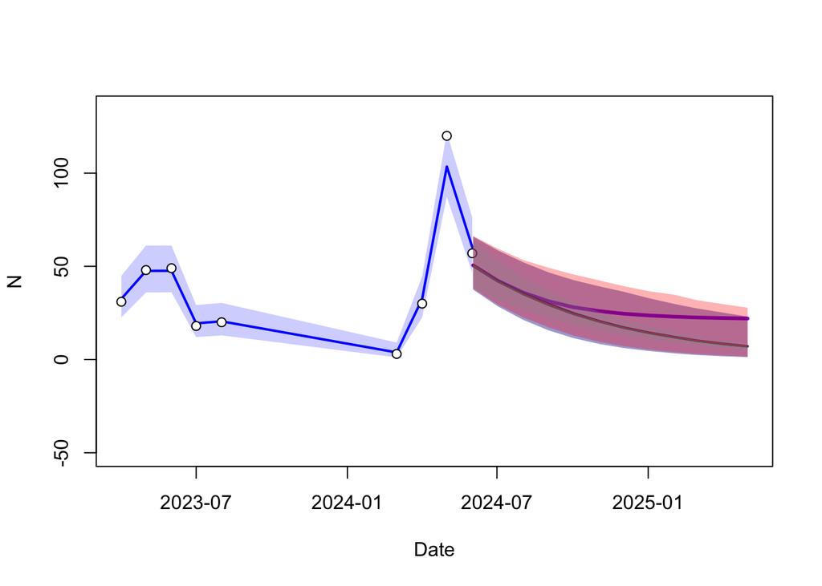

```r
zoomed_plot()

# Dark blue envelope for N.IPDE
ecoforecastR::ciEnvelope(future_dates, N.IPDE.ci[1,], N.IPDE.ci[3,],
                         col = rgb(0, 0, 0.6, 0.4))  # dark blue with transparency

# Median line in matching blue
lines(future_dates, N.IPDE.ci[2,], lwd = 2, col = "darkblue")

# Optionally overlay earlier layers
ecoforecastR::ciEnvelope(future_dates, N.IP.ci[1,], N.IP.ci[3,], col = rgb(1, 0, 0, 0.3))  # red
lines(future_dates, N.IP.ci[2,], lwd = 1, col = "red")

ecoforecastR::ciEnvelope(future_dates, N.I.ci[1,], N.I.ci[3,], col = rgb(0.6, 0.6, 0.6, 0.3))  # gray
lines(future_dates, N.I.ci[2,], lwd = 1, col = "gray40")
```

# Layer in random effect

Since we don’t have any random effect in the model, we’re going to add some noise to our sigma term to simulate that.

```r
n.mc <- 1000
steps <- 12
tau_forecast <- rep(1, steps)

rows <- sample(1:nrow(posterior), n.mc, replace = TRUE)

ICs    <- posterior[rows, "N[58]"]
rs     <- posterior[rows, "r"]
Ks     <- posterior[rows, "K"]
sigmas <- posterior[rows, "sigma"]

# Simulate added random-effect variance (+/- 20% around sigma)
rand_sigma <- sigmas * runif(n.mc, 0.8, 1.2)

# Forecast
N.IPDEA <- forecastN(IC = ICs, r = rs, K = Ks, sigma = rand_sigma,
                     tau = tau_forecast, n = n.mc, steps = steps)

# Summarize
N.IPDEA.ci <- apply(N.IPDEA, 2, quantile, probs = c(0.025, 0.5, 0.975))
```

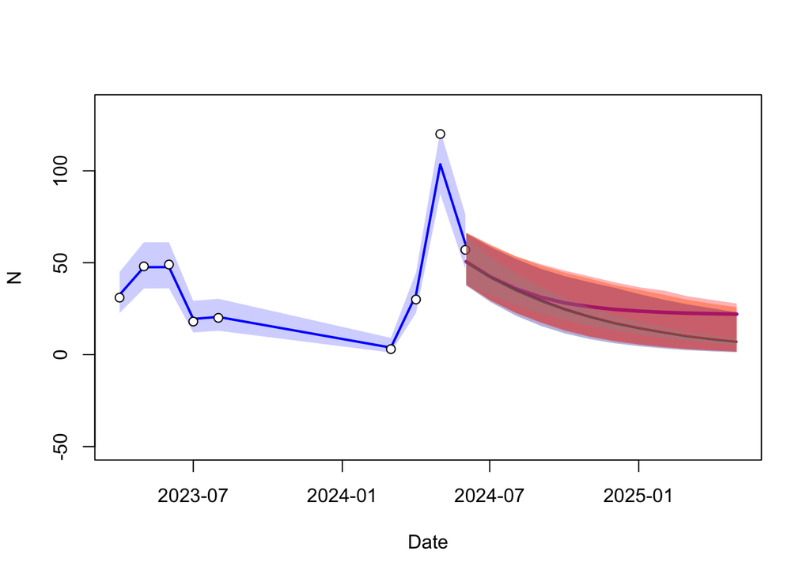

```r
zoomed_plot()

# Orange envelope for N.IPDEA
ecoforecastR::ciEnvelope(future_dates, N.IPDEA.ci[1,], N.IPDEA.ci[3,],
                         col = rgb(1, 0.5, 0, 0.4))  # semi-transparent orange
lines(future_dates, N.IPDEA.ci[2,], lwd = 2, col = "orange3")

# Layer earlier envelopes
ecoforecastR::ciEnvelope(future_dates, N.IPDE.ci[1,], N.IPDE.ci[3,], col = rgb(0, 0, 0.6, 0.3))  # dark blue
lines(future_dates, N.IPDE.ci[2,], lwd = 1, col = "darkblue")

ecoforecastR::ciEnvelope(future_dates, N.IP.ci[1,], N.IP.ci[3,], col = rgb(1, 0, 0, 0.3))        # red
lines(future_dates, N.IP.ci[2,], lwd = 1, col = "red")

ecoforecastR::ciEnvelope(future_dates, N.I.ci[1,], N.I.ci[3,], col = rgb(0.6, 0.6, 0.6, 0.3))    # gray
lines(future_dates, N.I.ci[2,], lwd = 1, col = "gray40")
```

# Stacked Error Partitions

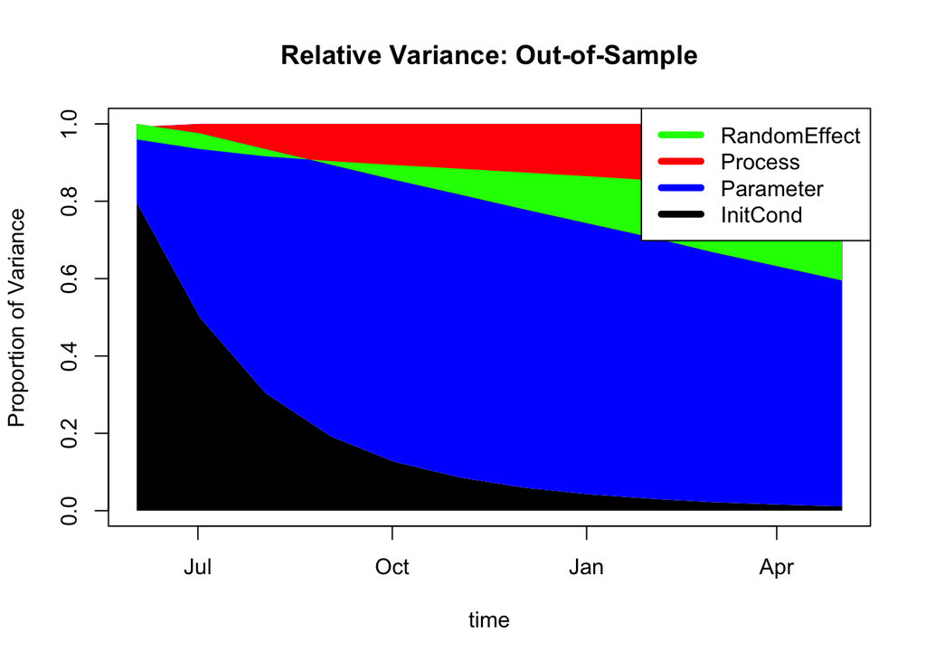

```r
### calculation of variances
varI     <- apply(N.I,2,var)
varIP    <- apply(N.IP,2,var)
varIPDE   <- apply(N.IPDE,2,var)
varIPDEA <- apply(N.IPDEA,2,var)
varMat   <- rbind(varI,varIP,varIPDE,varIPDEA)

## out-of-sample stacked area plot
V.pred.rel <- apply(varMat,2,function(x) {x/max(x)})
plot(future_dates,V.pred.rel[1,],ylim=c(0,1),type='n',main="Relative Variance: Out-of-Sample",ylab="Proportion of Variance",xlab="time")
ecoforecastR::ciEnvelope(future_dates,rep(0,ncol(V.pred.rel)),V.pred.rel[1,],col="black")
ecoforecastR::ciEnvelope(future_dates,V.pred.rel[1,],V.pred.rel[2,],col="blue")
ecoforecastR::ciEnvelope(future_dates,V.pred.rel[2,],V.pred.rel[3,],col="red")
ecoforecastR::ciEnvelope(future_dates,V.pred.rel[3,],V.pred.rel[4,],col="green")
legend("topright",legend=c("RandomEffect","Process","Parameter","InitCond"),col=c("green", "red", "blue", "black"),lty=1,lwd=5)
```